Category

Performance

Record & Time

We’ll look at a few graphics that map performance metrics to grades. Now, we know that when the Avs did well, they probably had better grades. My data curiosity just wanted to see it through.  
Now, performance can be measured in many different ways. For here, we’ll just keep it at *record* and *scoring differential*.  
Below, you can see how the grades map to the monthly record.

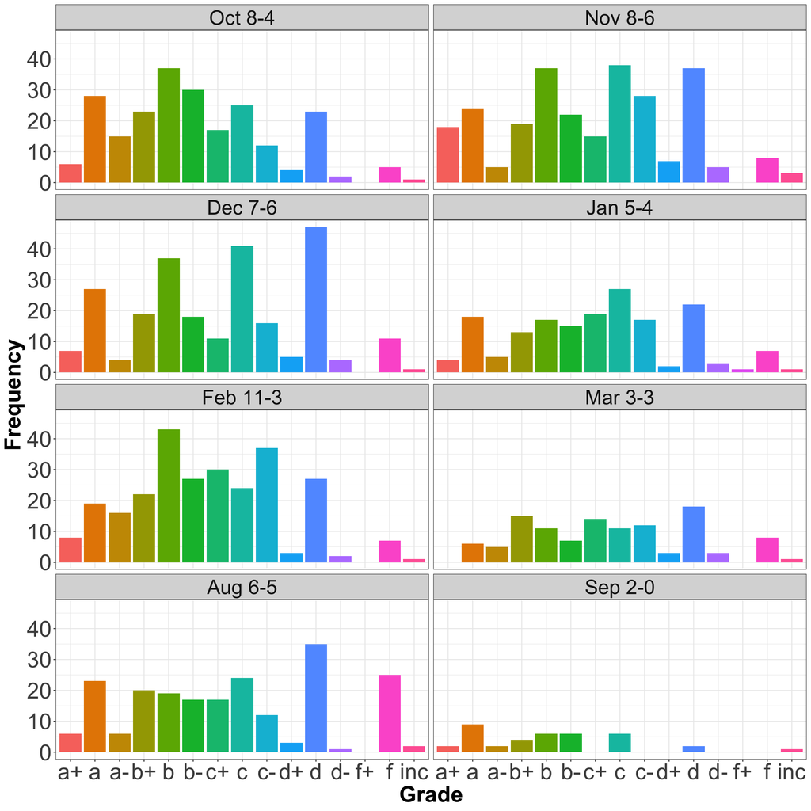

It appears that shift slightly left with a better record.  
For what it’s worth, it also appears that there is a higher proportion of *partial grades* as the season went on. I always wondered if the tendency to issue *partial grades* would be affected over time.

Performance by Scoring Differential

How about **scoring differential?** It adds a more information about a game, than just whether it was a win, or a loss - while inferring outcome.

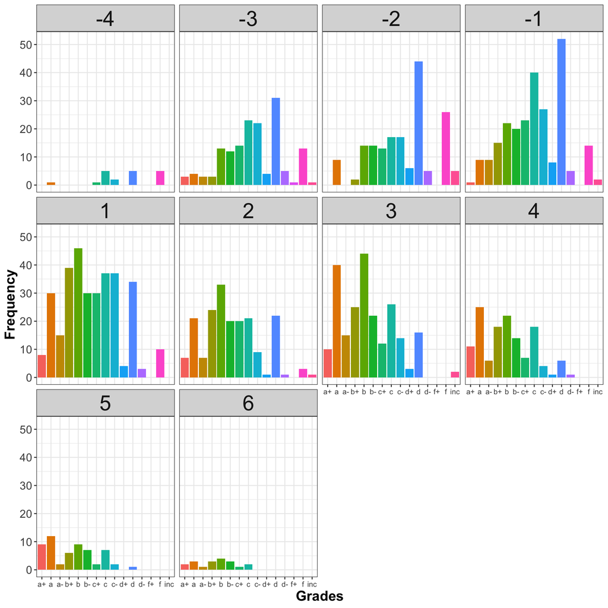

As expected, the grades shift towards the left *(higher)* when the Avs’ scoring differential is higher.  
However, it’s still a little hard to see. To make it easier, I mapped the grades to a common **GPA** system *(0-4)*.

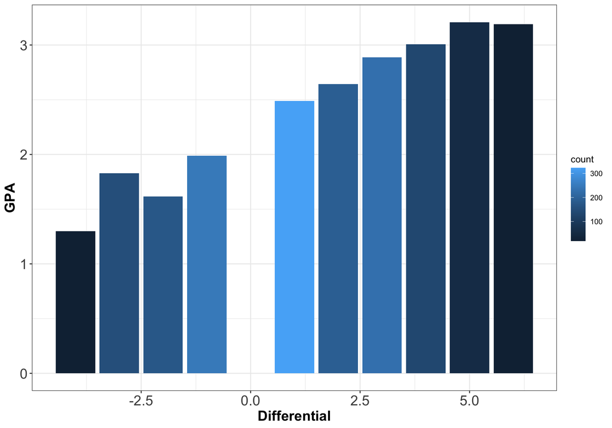

Also as expected, it appears that as scoring differential improves, so does the GPA.